# Act Report

#### by Suelen Fenali

WeRateDogs is a Twitter account that rates dogs pictures. Sometimes the picture gets very different ratings going beyond a 10 point scale, and why? Because, dogs deserve it!

After collecting data from different sources, it was possible to analyze the breeds most rated, and it will be shown as follows.

The first chart shows which are the Top 5 breeds more rated in WeRateDogs account, and the leading one is Golden Retriever with 158 tweets, around 8% of the posts.

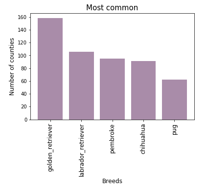

```python
from IPython.display import Image
Image('images/insight_1.png')
```

Another interesting Top 5 is the breeds with the best rating, which was calculated by dividing the rating numerator by the rating denominator (in order to bring all of them to the same scale), and then getting the median rating for each breed.

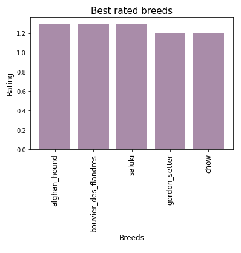

```python
Image('images/insight_2.png')
```

People usually interact with a tweet in two main ways: by retweeting it and by favoriting it. Analysing the data from WeRateDogs, it was possible to discover that the breed most retweeted and favorited was the French bulldog, which is no surprise, since they are so cute. Along with the graph, it's possible to see the most popular French bulldog in this dataset.

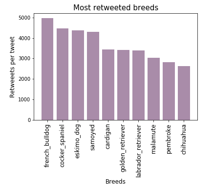

```python
Image('images/retweeted.png')
```

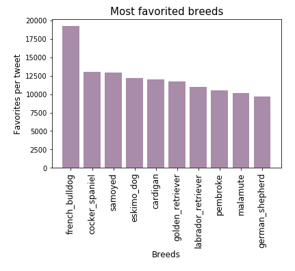

```python
Image('images/favorited.png')
```

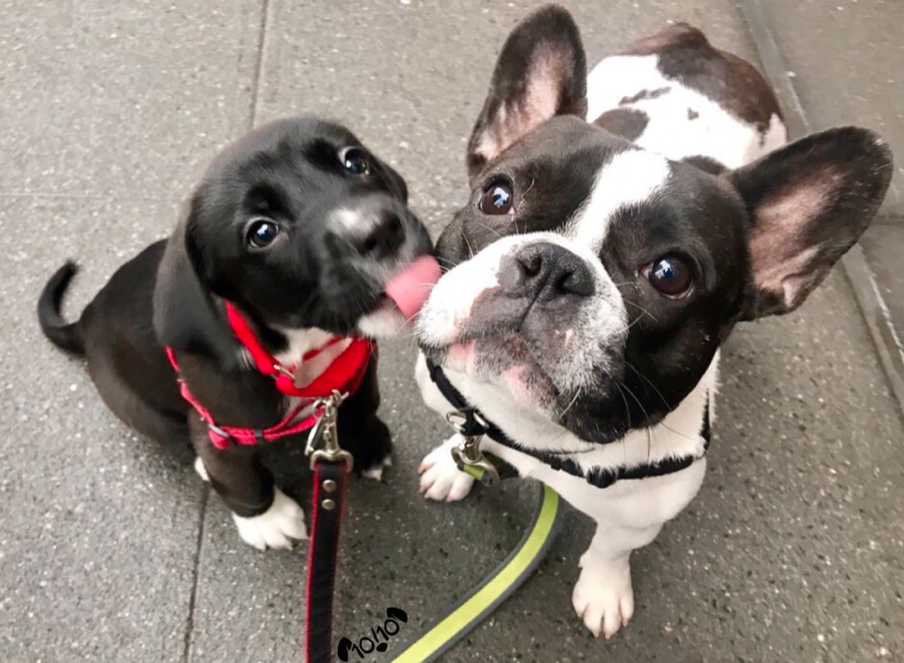

```python
Image('images/french_bulldog.png')
```

The data gathered with the breed prediction for each dog showed a confidence level. It could be expected that some breeds were easier or more difficult to predict. In the chart below, there are the five easiest breeds to predict in the dataset used. The first one is the `Komodor`, which makes much sense, since more peculiar dog breeds could be clear to identify. After the chart, a picture of a Komodor from one of the tweets is displayed.

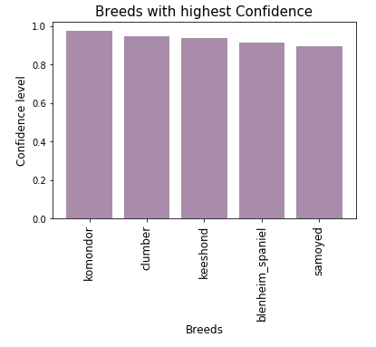

```python
Image('images/insight_4.png')
```

[figure not shown]

```python
Image('images/komondor.jpg')
```

Analysing data is a very exciting job, even more when it's possible to understand people's behavior while interacting with this sweet animals.

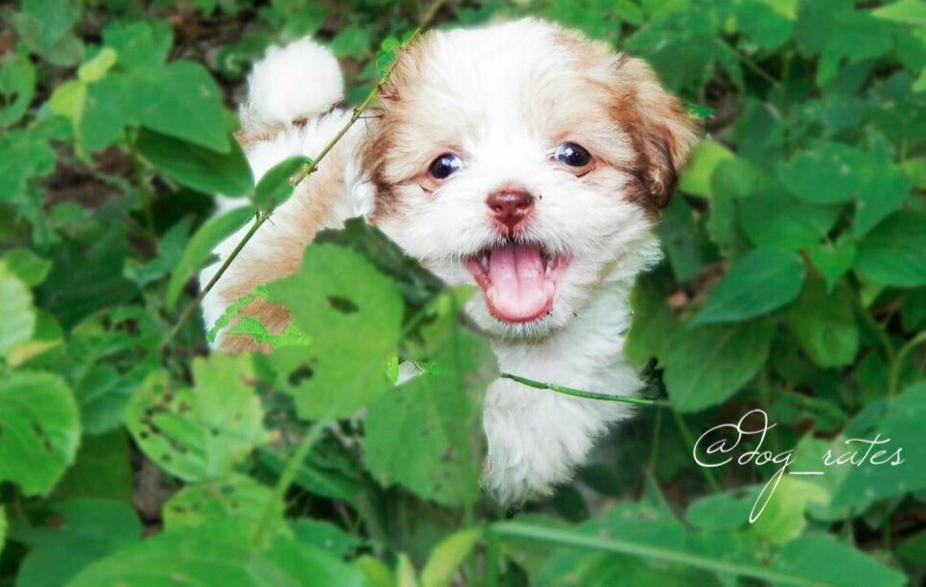

```python
Image('images/clumber.png')
```